# What we can do with Phonotacticon

Ian Joo (Otaru University of Commerce)

Linguistic data and language comparison in light of the ‘quantitative turn’ and ‘big data’. May 9 2025, Bern

# Data

Load tidyverse.

```r
library(tidyverse)
```

Load Phonotacticon.

```r
Phonotacticon <- read_csv('Phonotacticon1_0.csv', show_col_types = FALSE)

Phonotacticon
```

| Glottocode | ISO | Lect | lon | lat | Macroarea | Family | Type | Author | Year | Title | Publisher | School | Booktitle | Editor | Journal | Pages | Volume | Number | Edition | Phoneme | Tone | High | Onset | Nucleus | Coda | Note |
| --- | --- | --- | --- | --- | --- | --- | --- | --- | --- | --- | --- | --- | --- | --- | --- | --- | --- | --- | --- | --- | --- | --- | --- | --- | --- | --- |
| aoua1234 | aou | A'ou | 105.850000 | 26.800000 | Eurasia | Tai-Kadai | BOOK | Li, Xia and Li, Jinfang and Luo, Yongxian | 2014 | A Grammar of Zoulei (Southwest China) | Peter Lang | NA | NA | NA | NA | NA | NA | NA | NA | p t k q ʔ pʰ tʰ kʰ qʰ d t͡s t͡ɕ t͡sʰ t͡ɕʰ m n ŋ l ɭ f s ɬ ɕ χ h v z ʑ ɣ ʁ w j a e i ɯ ɔ u ɤ ə o | 55 33 13 31 | 5 | p t k q ʔ pʰ tʰ kʰ qʰ d t͡s t͡ɕ t͡sʰ t͡ɕʰ m n ŋ l ɭ f s ɬ ɕ χ h v z ʑ ɣ ʁ w j pl bl vl ml | a e i z ɔ u ai ei ui əu aɯ əɯ iu ɤu ia ie iɔ ua iau iəɯ iəu uai uau uəɯ uei | # n ŋ | NA |
| abaz1241 | abq | Abaza | 42.000000 | 44.250000 | Eurasia | Abkhaz-Adyge | INCOLLECTION | Lomtatidze, Ketevan and Klychev, Rauf | 1989 | Abaza | Caravan Books | NA | The indigenous languages of the Caucasus | Hewitt, B. George | NA | 89--154 | NA | NA | 1 | b p pʼ d t tʼ d͡z t͡s t͡sʼ d͡ʑ t͡ɕ t͡ɕ d͡ʑʷ t͡ɕʷ t͡ɕʼʷ d͡ʒ t͡ʃ t͡ʃʼ ɡ k kʼ ɡʲ kʲ kʼʲ ɡʷ kʷ kʼʷ q qʼ qʼʲ qʷ qʼʷ ʔ f z s ʑ ɕ ʒ ʃ ʑʷ ɕʷ ɣ x ɣʲ xʲ ɣʷ xʷ ʕ ħ ʕʷ ħʷ m n l w j r v fʼ ʟ t͡ɬ t͡ɬʼ ç çʷ ə a | - | NA | ? | ? | ? | ``Lamino-post-alveolar'' and ``apico-palatal'' are interpreted as alveolo-palatal and palato-alveolar, respectively. ``Fronted dorso-velar'' is interpreted as palatalized velar. The ``[d]orso-palatal … |
| abkh1244 | abk | Abkhaz | 41.159115 | 43.056218 | Eurasia | Abkhaz-Adyge | BOOK | Chirikba, Viacheslav | 2003 | Abkhaz | Lincom Europa | NA | NA | NA | NA | NA | NA | NA | NA | b p pˀ m w v f d t tˀ d̪ʷ t̪ʷ t̪ʷˀ d̪͡z̪ t̪͡s̪ t̪͡s̪ˀ d̪͡z̪ʷ t̪͡s̪ʷ t̪͡w̪ʷˀ z̪ s̪ n̪ r̪ d͡z t͡s t͡sˀ d͡zʲ t͡sʲ t͡sʲˀ z s zʷ sʷ zʲ sʲ j jʷ l ɡ k kˀ ɡʷ kʷ kʷˀ ɡʲ kʲ kˀʲ qˀ qʷˀ qʲˀ ɣ x ɣʷ xʷ ɣʲ xʲ ħ ħʷ ə… | - | NA | ? | ? | ? | NA |
| adyg1241 | ady | Adyghe | 39.330000 | 44.000000 | Eurasia | Abkhaz-Adyge | BOOK | Smeets, Henricus Joannes | 1984 | Studies in West Circassian phonology and morphology | Hakuchi Press | NA | NA | NA | NA | NA | NA | NA | NA | p b pˀ pʷˀ f fʷ m w t d tˀ tʷˀ t͡s d͡z t͡sˀ s z s n t͡ɕʷ d͡ʑʷ ɕ ʑ ɕˀ ɕʷ ʑʷ ɕʷˀ+W694 r c͡ç ɟ͡ʝ c͡çˀ ç çˠ ʝ i ɬ ɮ ɬʷ k ɡ kˀ kʷ ɡʷ kʷˀ x ɡ q qʷ χ ɢ χʷ ɢʷ ħ ʔ ʔʷ h ə e a | - | NA | ? | ə e a | ? | NA |
| akaj1239 | akj | Akajeru | 92.950400 | 13.152500 | Eurasia | Great Andamanese | BOOK | Abbi, Anvita | 2013 | A Grammar of the Great Andamanese Language: An Ethnolinguistic Study | Brill | NA | NA | NA | NA | NA | NA | NA | NA | p b t d ʈ ɖ c j k pʰ tʰ ʈʰ kʰ m n ɲ ŋ r s ʃ l j i u e o ɛ ɔ ɑ ɔː ɑː eː iː oː uː | - | NA | # p b t d ʈ ɖ c j k pʰ tʰ ʈʰ kʰ m n ɲ ŋ r s ʃ l j tr kʰr | i u e o ɛ ɔ ɑ ɔː ɑː eː iː oː uː ia iu io iːo ue iːe iɛ ei eo eɔ ea eu ɛo ɛo ɛi ɛːi ɛo ua uo uɔ ui ue oa oːa oɔ oːɔ ou oi oe oːe oɛ ɔi ɔːe ɔe ɔɛ ɔo ɔa ao aːo aːu au aɛ aːe ae ai aie aou aia aeo eia eoɛ… | # p b t d ʈ ɖ c j k m n ɲ ŋ r s l j | NA |
| amdo1237 | adx | Amdo Tibetan | 100.485000 | 34.517700 | Eurasia | Sino-Tibetan | BOOK | Ebihara, Shiho | 2019 | Amudo chibetto go bunpō アムド・チベット語文法 [Amdo Tibetan grammar] | Hitsuji shobō ひつじ書房 | NA | NA | NA | NA | NA | NA | NA | NA | p b pʰ t d tʰ ʈ ɖ ʈʰ k ɡ kʰ t͡s d͡z t͡sʰ t͡ɕ d͡ʑ t͡ɕʰ f s z sʰ ʂ ɕ ʑ ç χ ʁ h m n ɲ̟ ŋ l ɹ ɬ w j i y ɛ ɯ ə o ʌ | - | NA | # p b pʰ t d tʰ ʈ ɖ ʈʰ k ɡ kʰ t͡s d͡z t͡sʰ t͡ɕ d͡ʑ t͡ɕʰ f s z sʰ ʂ ɕ ʑ ç χ ʁ h m n ɲ̟ ŋ l ɹ ɬ w j nb npʰ nd ntʰ nɖ nʈʰ nɡ nkʰ hp ht hʈ hk nd͡ʑ nt͡ɕʰ nd͡z nt͡sʰ ht͡ɕ ht͡s hm hn hɲ̟ hŋ hl hj kw kʰw pj k… | i y ɛ ɯ ə o ʌ | # p k m n ŋ l ɹ | NA |
| gily1242 | niv | Amur Nivkh | 140.681000 | 52.590000 | Eurasia | Nivkh | BOOK | Ekaterina Gruzdeva | 1998 | Nivkh | Lincom | NA | NA | NA | NA | NA | NA | NA | NA | i ɨ u e o a b d ɟ ɡ ɢ p t c k q pʰ tʰ cʰ kʰ qʰ m n ɲ ŋ v z ɣ ʁ f s x χ h l j r̥ r | - | NA | # C CC | i ɨ u e o a | # C CC CCC | NA |
| andi1255 | ani | Andi | 46.291900 | 42.807800 | Eurasia | Nakh-Daghestanian | BOOK | Salimov Салимов, X. S. Х. С. | 2010 | Gagatlinskij govor andijskogo jazyka Гагатлинский говор андийского языка [Gagatli dialect of Andi language] | IJALI ИЯЛИ | NA | NA | NA | NA | NA | NA | NA | NA | i u e o a ĩ ũ ẽ õ ã b pʰ pʼ v m d tʰ tʼ z̪ z s̪ s s̪ː sː d͡z t̪͡s̪ t͡s t̪͡s̪ː t͡sː t̪͡s̪ʼ t͡sʼ t̪͡s̪ʼː t͡sʼː n r ɬ ɬː t͡ɬ t͡ɬʼ l ʝ ɡ kʰ kʼ xː k͡xː k͡xʼː ʁ χ χː ɢ͡ʁ q͡χː q͡χʼː ʔ ɦ h hː | - | NA | ? | ? | ? | ``Смычно-гортаные'' interpreted as ejective. |
| anga1288 | njm | Angami Naga | 93.866800 | 25.684100 | Eurasia | Sino-Tibetan | PHDTHESIS | Kuolie, Duovituo | 2004 | Structural description of Tenyidie: a Tibeto-Burman language of Nagaland | NA | Deccan College | NA | NA | NA | NA | NA | NA | NA | p b t d k ɡ pʰ tʰ kʰ m n ɲ ŋ m̥ n̥ ɲ̥ f v s z ç ʝ h p͡f b͡v t͡s d͡z c͡ç ɟ͡ʝ p͡fʰ t͡sʰ c͡çʰ l l̥ r r̥ w j w̥ j̥ i u e ə o ɜ a | H F M R L | NA | # p b t d k ɡ pʰ tʰ kʰ m n ɲ ŋ m̥ n̥ ɲ̥ f v s z ç ʝ h p͡f b͡v t͡s d͡z c͡ç ɟ͡ʝ p͡fʰ t͡sʰ c͡çʰ l l̥ r r̥ w j w̥ j̥ pr pʰr kr kʰr | i u e ə o ɜ a ie uo | # | NA |
| aona1235 | njo | Ao Naga | 94.382400 | 26.324100 | Eurasia | Sino-Tibetan | BOOK | Coupe, Alexander Robertson | 2007 | A Grammar of Mongsen Ao | Mouton de Gruyter | NA | NA | NA | NA | NA | NA | NA | NA | p pʰ t tʰ k kʰ t͡s t͡sʰ t͡ʃ t͡ʃʰ m n ŋ m̥ n̥ ŋ̥ z s h w l ɹ j ʍ l̥ ɹ̥ j̥ i u ə a a̰ | H M L | NA | # p pʰ t tʰ k kʰ t͡s t͡sʰ t͡ʃ t͡ʃʰ m n ŋ m̥ n̥ ŋ̥ z s h w l ɹ j ʍ l̥ ɹ̥ j̥ | i u ə a a̰ Vw Vj | # p t k m n ŋ ɹ | NA |

[output cut: 506 more lines]

Load split segments.

```r
Segments <- read_csv('Phonotacticon1_0Segments.csv', show_col_types = FALSE)

Segments
```

| Sequence | Order | Lect | Category | ipa |
| --- | --- | --- | --- | --- |
| mp | 1 | Bezhta | Coda | m |
| np | 1 | Bezhta | Coda | n |
| wp | 1 | Bezhta | Coda | w |
| jp | 1 | Bezhta | Coda | j |
| lp | 1 | Bezhta | Coda | l |
| rp | 1 | Bezhta | Coda | r |
| mb | 1 | Bezhta | Coda | m |
| nb | 1 | Bezhta | Coda | n |
| wb | 1 | Bezhta | Coda | w |
| jb | 1 | Bezhta | Coda | j |

[output cut: 9990 more lines]

Load map data.

```r
map <- map_data("world")

head(map)
```

|  | long | lat | group | order | region | subregion |
| --- | --- | --- | --- | --- | --- | --- |
| 1 | -69.89912 | 12.45200 | 1 | 1 | Aruba | NA |
| 2 | -69.89571 | 12.42300 | 1 | 2 | Aruba | NA |
| 3 | -69.94219 | 12.43853 | 1 | 3 | Aruba | NA |
| 4 | -70.00415 | 12.50049 | 1 | 4 | Aruba | NA |
| 5 | -70.06612 | 12.54697 | 1 | 5 | Aruba | NA |
| 6 | -70.05088 | 12.59707 | 1 | 6 | Aruba | NA |

Create a map of Eurasia.

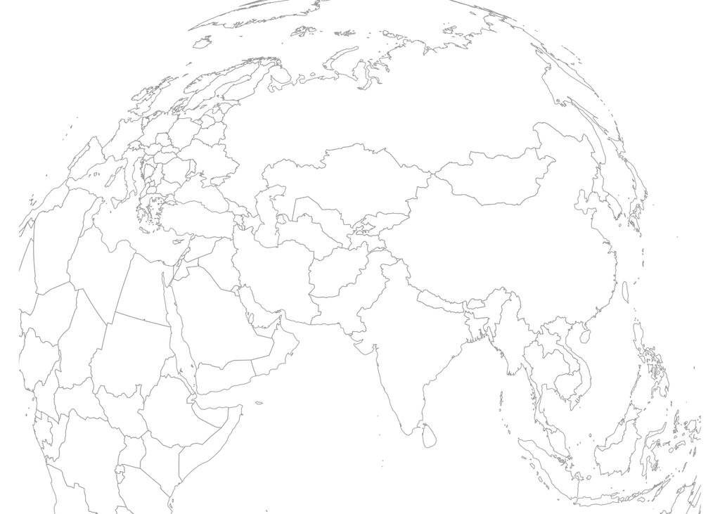

```r
EurasiaMap <- ggplot(map, aes(x = long, y = lat)) +
  geom_polygon(aes(group = group),
               fill = "white",
               color = "darkgrey",
               linewidth = 0.2) +
  coord_map("ortho",
            orientation = c(20, 70, 0),
            xlim = c(10, 130),
            ylim = c(0, 90)) +
  theme_void()

EurasiaMap
```

Load PanPhon.

```r
PanPhon <- read_csv("PanPhonPhonotacticon1_0.csv", show_col_types = FALSE) %>%
  unique(by = 'ipa')

PanPhon
```

| ipa | syl | son | cons | cont | delrel | lat | nas | strid | voi | sg | cg | ant | cor | distr | lab | hi | lo | back | round | velaric | tense | long |
| --- | --- | --- | --- | --- | --- | --- | --- | --- | --- | --- | --- | --- | --- | --- | --- | --- | --- | --- | --- | --- | --- | --- |
| q | -1 | -1 | 1 | -1 | -1 | -1 | -1 | 0 | -1 | -1 | -1 | -1 | -1 | 0 | -1 | -1 | -1 | 1 | -1 | -1 | 0 | -1 |
| q̟ | -1 | -1 | 1 | -1 | -1 | -1 | -1 | 0 | -1 | -1 | -1 | -1 | -1 | 0 | -1 | -1 | -1 | 1 | -1 | -1 | 0 | -1 |
| q̠ | -1 | -1 | 1 | -1 | -1 | -1 | -1 | 0 | -1 | -1 | -1 | -1 | -1 | 0 | -1 | -1 | -1 | 1 | -1 | -1 | 0 | -1 |
| ɢ | -1 | -1 | 1 | -1 | -1 | -1 | -1 | 0 | 1 | -1 | -1 | -1 | -1 | 0 | -1 | -1 | -1 | 1 | -1 | -1 | 0 | -1 |
| ɢ̟ | -1 | -1 | 1 | -1 | -1 | -1 | -1 | 0 | 1 | -1 | -1 | -1 | -1 | 0 | -1 | -1 | -1 | 1 | -1 | -1 | 0 | -1 |
| ɢ̠ | -1 | -1 | 1 | -1 | -1 | -1 | -1 | 0 | 1 | -1 | -1 | -1 | -1 | 0 | -1 | -1 | -1 | 1 | -1 | -1 | 0 | -1 |
| qː | -1 | -1 | 1 | -1 | -1 | -1 | -1 | 0 | -1 | -1 | -1 | -1 | -1 | 0 | -1 | -1 | -1 | 1 | -1 | -1 | 0 | 1 |
| ɢː | -1 | -1 | 1 | -1 | -1 | -1 | -1 | 0 | 1 | -1 | -1 | -1 | -1 | 0 | -1 | -1 | -1 | 1 | -1 | -1 | 0 | 1 |
| ʈ | -1 | -1 | 1 | -1 | -1 | -1 | -1 | 0 | -1 | -1 | -1 | -1 | 1 | -1 | -1 | -1 | -1 | -1 | -1 | -1 | 0 | -1 |
| ʈ̟ | -1 | -1 | 1 | -1 | -1 | -1 | -1 | 0 | -1 | -1 | -1 | -1 | 1 | -1 | -1 | -1 | -1 | -1 | -1 | -1 | 0 | -1 |

[output cut: 9990 more lines]

Subset lects and coordinatees from Phonotacticon.

```r
Lect_LonLat <- Phonotacticon %>%
  select(Lect, lon, lat)

Lect_LonLat
```

| Lect | lon | lat |
| --- | --- | --- |
| A'ou | 105.850000 | 26.800000 |
| Abaza | 42.000000 | 44.250000 |
| Abkhaz | 41.159115 | 43.056218 |
| Adyghe | 39.330000 | 44.000000 |
| Akajeru | 92.950400 | 13.152500 |
| Amdo Tibetan | 100.485000 | 34.517700 |
| Amur Nivkh | 140.681000 | 52.590000 |
| Andi | 46.291900 | 42.807800 |
| Angami Naga | 93.866800 | 25.684100 |
| Ao Naga | 94.382400 | 26.324100 |

[output cut: 506 more lines]

# Onset-coda asymmetry

Show segments that appear (as singleton segments) only in onset or coda position.

```r
OnsetCoda <- Segments %>%
  filter(Category %in% c('Onset', 'Coda')) %>%
  group_by(Sequence) %>%
  filter(max(Order) == 1) %>%
  ungroup() %>%
  select(-Order, -Sequence) %>%
  mutate(Presence = TRUE) %>%
  pivot_wider(id_cols = c('Lect', 'ipa'),
              values_from = Presence,
              names_from = Category,
              values_fn = all) %>%
  mutate(OnlyOnset = Onset & is.na(Coda),
         OnlyCoda = Coda & is.na(Onset)) %>%
  group_by(ipa) %>%
  summarise(OnlyOnset = sum(OnlyOnset),
            OnlyCoda = sum(OnlyCoda)) %>%
  filter(OnlyOnset > 0 | OnlyCoda > 0) %>%
  arrange(-OnlyCoda, -OnlyOnset)

OnsetCoda
```

| ipa | OnlyOnset | OnlyCoda |
| --- | --- | --- |
| # | 0 | 73 |
| ŋ | 25 | 41 |
| ʔ | 50 | 28 |
| ɳ | 6 | 10 |
| j | 117 | 8 |
| w | 110 | 7 |
| r | 25 | 6 |
| i | 3 | 5 |
| ɲ | 87 | 4 |
| ɽ | 5 | 4 |

[output cut: 276 more lines]

# Sonority Sequencing Principle

Define classes.

```r
Classes <- PanPhon %>%
  mutate(Glide = grepl('j|w|ɥ|ɰ', ipa),
        Liquid = cons == 1 & cont == 1 & cor == 1 & son == 1,
        Nasal = nas == 1 & syl == -1,
        Obstruent = cons == 1 & son != 1,
        Vowel = cons == -1 & cont == 1 & son == 1 & syl == 1) %>%
  select(ipa, Glide, Liquid, Nasal, Obstruent, Vowel) %>%
  pivot_longer(cols = -ipa,
     names_to = 'Class',
     values_to = 'Value') %>%
  filter(Value) %>%
  select(-Value) %>%
  group_by(Class) %>%
  summarise(ipa = list(ipa), .groups = 'drop') %>%
  deframe()

Classes[1]
```

```
## $Glide
##   [1] "ɰ̥"   "ɰ"   "ɰ̝"   "ɰ̞"   "ɰ̟"   "ɰ̠"   "ɰ̥ː"  "ɰː"  "ɰ̥ʲ"  "ɰʲ"  "ɰːʲ" "ɰʲː"
##  [13] "ɰᶣ"  "ɰ̥ˠ"  "ɰːˠ" "ɰ̥ʷ"  "ɰʷˠ" "ɰʲʷ" "ɰʷ"  "ɰʷː" "ɰːʷ" "ɥ̥ʲ"  "ɥ̥"   "ɥ"
##  [25] "ɥ̝"   "ɥ̞"   "ɥ̟"   "ɥ̠"   "ɥ̥ː"  "ɥː"  "ɥːʲ" "ɥ̥ʷ"  "ɥ̥ˠ"  "ɥˠ"  "ɥːʷ" "ɥːˠ"
##  [37] "ɰ̥ˤ"  "ɰˤ"  "ɰːˤ" "ɰˤː" "ɰʷˤ" "ɥ̥ˤ"  "ɥˤ"  "ɥːˤ" "ɥˤː" "ɰ̰"   "ɰˀ"  "ʔ͡ɰ"
##  [49] "ɰ̰ː"  "ɰ̰ʲ"  "ɰ̰ˠ"  "ɰʷˀ" "ɰ̰ʷ"  "ɥ̰"   "ɥˀ"  "ʔ͡ɥ"  "ɥ̰ʲ"  "ɥ̰ː"  "ɥ̰ˠ"  "ɥ̰ʷ"
##  [61] "ɰ̰ˤ"  "ɥ̰ˤ"  "ɰ̤̥"   "ɰ̤"   "ɰ̤ː"  "ɰ̤ʲ"  "ɰ̤ˠ"  "ɰ̤ʷ"  "ɥ̤̥"   "ɥ̤"   "ɥ̤ʲ"  "ɥ̤ː"
##  [73] "ɥ̤ʷ"  "ɥ̤ˠ"  "ɰ̤ˤ"  "ɥ̤ˤ"  "ɰ̃"   "ɰ̃ː"  "ɥ̃"   "ɥ̃ː"  "ɰ̃ˤ"  "ɥ̃ˤ"  "ɰ̰̃"   "ɥ̰̃"
##  [85] "j̥ʲ"  "j̥"   "j"   "j̝"   "j̞"   "j̟"   "j̠"   "j̥ː"  "jː"  "jːʲ" "jᶣ"  "j̥ˠ"
##  [97] "jˠ"  "jːˠ" "j̥ʷ"  "jʷˠ" "jʷ"  "jːʷ" "jʷː" "w̥ʲ"  "wʲ"  "wːʲ" "wʲː" "w̥ʷ"
## [109] "w̥ˠ"  "w̥"   "wˠ"  "w"   "w̝"   "w̞"   "w̟"   "wʲʷ" "w̠"   "w̥ː"  "wːʷ" "wː"
## [121] "wːˠ" "j̥ˤ"  "jˤ"  "jːˤ" "jˤː" "jʷˤ" "w̥ˤ"  "wˤ"  "wːˤ" "wˤː" "j̰"   "jˀ"
## [133] "ʔ͡j"  "j̰ʲ"  "j̰ː"  "j̰ˠ"  "jʷˀ" "j̰ʷ"  "w̰ʲ"  "w̰ˠ"  "w̰"   "wˀ"  "ʔ͡w"  "w̰ʷ"
## [145] "w̰ː"  "j̰ˤ"  "w̰ˤ"  "j̤̥"   "j̤"   "j̤ʲ"  "j̤ː"  "j̤ˠ"  "j̤ʷ"  "w̤ʲ"  "w̤̥"   "w̤"
## [157] "w̤ʷ"  "w̤ˠ"  "w̤ː"  "j̤ˤ"  "w̤ˤ"  "j̃"   "j̃ː"  "w̃"   "w̃ː"  "j̃ˤ"  "w̃ˤ"  "j̰̃"
## [169] "w̰̃"   "ɰ̩"   "ɥ̩"   "j̩"   "w̩"
```

Show the percentage of complex onsets and codas not violating the Sonority Sequencing Principle in each lect.

```r
Sonority <- Segments %>%
  group_by(Sequence) %>%
  filter(max(Order) >= 2 & Category != 'Nucleus') %>%
  left_join(PanPhon) %>%
  mutate(Sonority =
           ifelse(ipa %in% Classes$Vowel, 4,
                  ifelse(ipa %in% Classes$Glide, 3,
                         ifelse(ipa %in% Classes$Liquid, 2,
                                ifelse(ipa %in% Classes$Nasal, 1,
                                       ifelse(ipa %in% Classes$Obstruent, 0, NA)))))) %>%
  filter(!is.na(Sonority)) %>%
  select(Lect, Category, Sequence, Order, Sonority) %>%
  arrange(Sequence, Order) %>%
  group_by(Sequence) %>%
  mutate(Previous = lag(Sonority)) %>%
  filter(!is.na(Previous)) %>%
  mutate(SSP = (Category == 'Onset' & Sonority >= Previous) |
         (Category == 'Coda' & Sonority <= Previous)) %>%
  group_by(Lect) %>%
  summarise(Percentage = 100 * sum(SSP)/n()) %>%
  left_join(Lect_LonLat) %>%
  arrange(Percentage)
Sonority
```

| Lect | Percentage | lon | lat |
| --- | --- | --- | --- |
| Wuding-Luquan Yi | 0.00000 | 102.48000 | 25.48000 |
| Chak | 53.43246 | 92.59530 | 21.41340 |
| Pa-Hng | 72.72727 | 105.16500 | 22.80490 |
| Daai Chin | 81.48148 | 93.78530 | 20.73470 |
| Amdo Tibetan | 81.81818 | 100.48500 | 34.51770 |
| Ersu | 84.21053 | 102.21300 | 29.28670 |
| Hmong Njua | 85.00000 | 101.95000 | 22.56380 |
| Aromanian | 85.10029 | 21.20000 | 40.61600 |
| Laz | 85.71429 | 41.90960 | 41.50040 |
| Longchuan Achang | 85.71429 | 97.74380 | 24.34790 |

[output cut: 240 more lines]

Visualize the percentages.

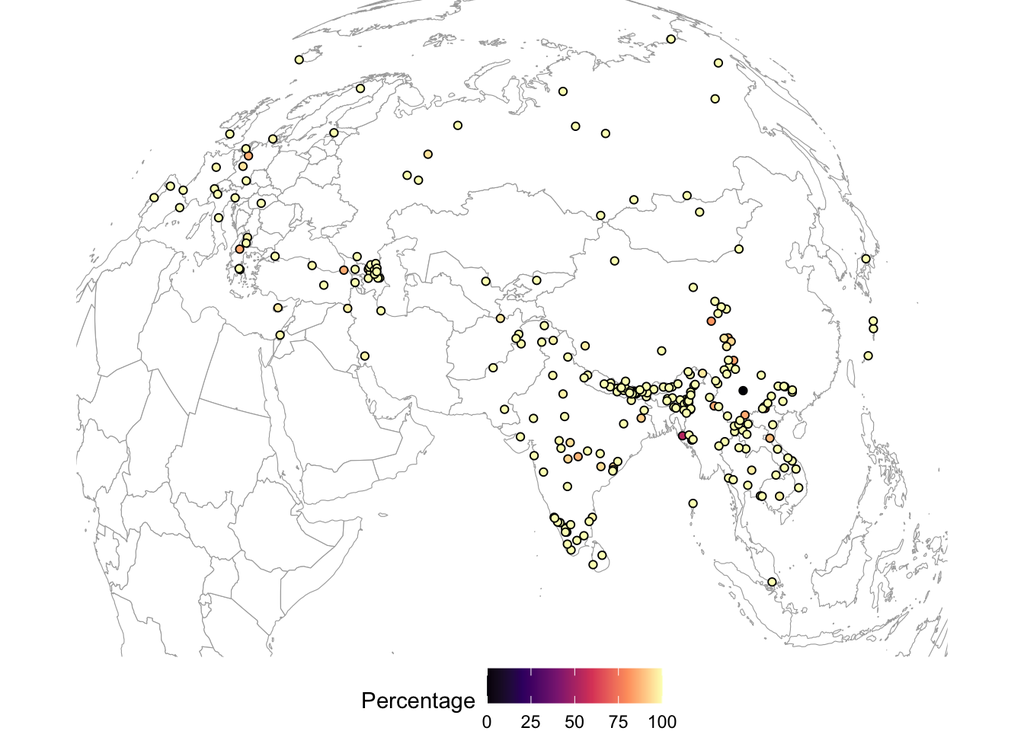

```r
EurasiaMap +
  geom_point(data = Sonority,
             aes(x = lon, y = lat, fill = Percentage),
             shape = 21) +
  scale_fill_viridis_c(option = 'magma') +
  theme(legend.position = "bottom")
```

# Syllabic consonants

Show the number of occurrence of each syllabic consonant.

```r
SylC <- Segments %>%
  group_by(Sequence) %>%
  filter(max(Order) == 1 &
           Category == 'Nucleus' &
          !ipa %in% Classes$Vowel) %>%
  group_by(ipa) %>%
  summarise(Number = n()) %>%
  arrange(-Number)

SylC
```

| ipa | Number |
| --- | --- |
| m | 37 |
| n | 31 |
| z | 31 |
| ŋ | 30 |
| v | 11 |
| l | 10 |
| r | 9 |
| ɲ | 7 |
| ʐ | 6 |
| p | 5 |

[output cut: 99 more lines]

# Opening and closing diphthongs

Count the number of opening, closing, or flat diphthongs per lect.

```r
Diphthong <- Segments %>%
  group_by(Sequence) %>%
  filter(Category == 'Nucleus' &
           max(Order) == 2) %>%
  left_join(PanPhon) %>%
  select(Sequence, Lect, ipa, Order, hi, lo) %>%
  group_by(Sequence, Lect) %>%
  mutate(hilag = lag(hi),
         lolag = lag(lo)) %>%
  filter(Order == 2) %>%
  ungroup() %>%
  mutate(Shape = ifelse(hi > hilag | lo < lolag, 'Closing',
                        ifelse(hi < hilag | lo > lolag, 'Opening', 'Flat'))) %>%
  group_by(Lect, Shape) %>%
  count() %>%
  left_join(Lect_LonLat)
Diphthong
```

| Lect | Shape | n | lon | lat |
| --- | --- | --- | --- | --- |
| A'ou | Closing | 6 | 105.85000 | 26.800000 |
| A'ou | Flat | 2 | 105.85000 | 26.800000 |
| A'ou | Opening | 4 | 105.85000 | 26.800000 |
| Akajeru | Closing | 15 | 92.95040 | 13.152500 |
| Akajeru | Flat | 14 | 92.95040 | 13.152500 |
| Akajeru | Opening | 13 | 92.95040 | 13.152500 |
| Angami Naga | Opening | 2 | 93.86680 | 25.684100 |
| Ao Naga | Closing | 6 | 94.38240 | 26.324100 |
| Ao Naga | Flat | 4 | 94.38240 | 26.324100 |
| Aromanian | Closing | 8 | 21.20000 | 40.616000 |

[output cut: 421 more lines]

Visualize the distribution of diphthong types.

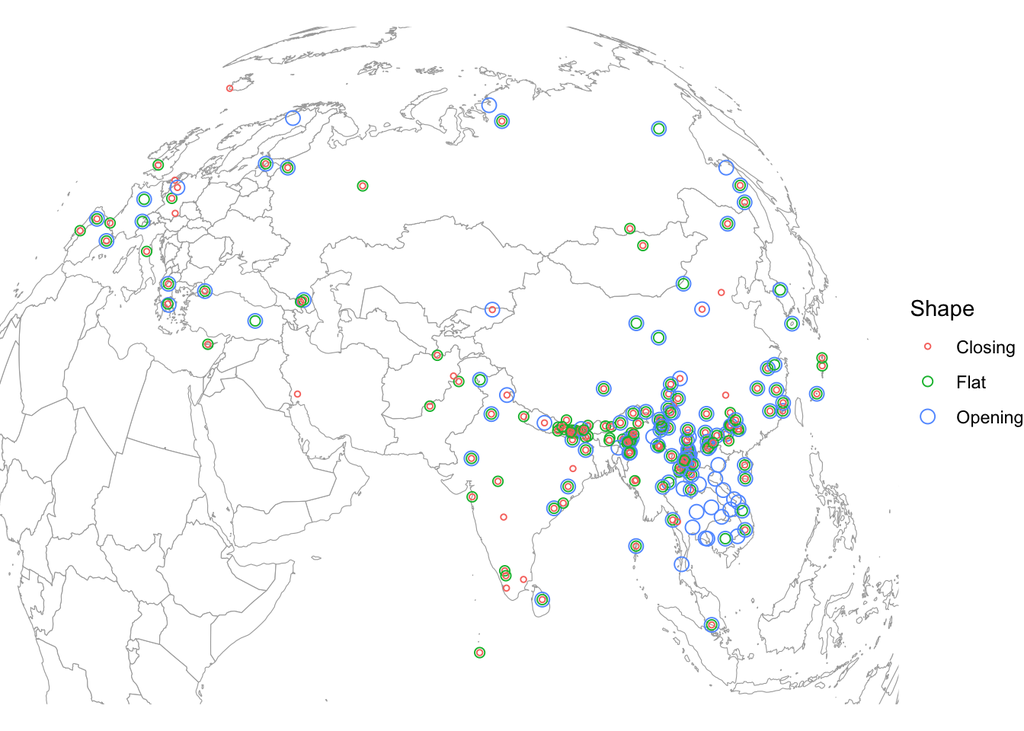

```r
EurasiaMap +
  geom_point(data = Diphthong,
             aes(x = lon, y = lat, size = Shape, color = Shape),
             shape = 1) +
  scale_size_manual(values = c(1, 2, 3))
```

# Positional asymmetry in onset and coda clusters

Count lects with “decreasing” bisegmental onset/coda clusters (i.e. whose first segment is more diverse than the second) and those with “increasing” bisegmental onset/coda clusters.

```r
Clusters <- Segments %>%
  group_by(Sequence) %>%
  filter(Category != 'Nucleus' &
           max(Order) == 2) %>%
  ungroup() %>%
  group_by(Lect, Order, Category) %>%
  summarise(ipa = n_distinct(ipa)) %>%
  pivot_wider(names_from = Order, values_from = ipa) %>%
  mutate(Shape = ifelse(`1` < `2`, 'Increasing',
                        ifelse( `1` > `2`, 'Decreasing', 'Flat'))) %>%
  group_by(Category, Shape) %>%
  count() %>%
  group_by(Category) %>%
  pivot_wider(id_cols = Category, names_from = Shape, values_from = n)
Clusters
```

| Category | Decreasing | Flat | Increasing |
| --- | --- | --- | --- |
| Coda | 29 | 16 | 72 |
| Onset | 154 | 14 | 40 |

# Segmental collocations in bisegmental onset/coda clusters

Calculate the frequency order of the first segments in bisegmental onset clusters.

```r
OnsetFirst <- Segments %>%
  filter(Category == 'Onset') %>%
  group_by(Sequence) %>%
  filter(max(Order) == 2) %>%
  ungroup() %>%
  filter(Order == 1) %>%
  group_by(ipa) %>%
  summarise(n = n()) %>%
  arrange(-n) %>%
  select(-n) %>%
  mutate(Order = 1:nrow(.)) %>%
  rename(First = ipa)

OnsetFirst
```

| First | Order |
| --- | --- |
| k | 1 |
| s | 2 |
| p | 3 |
| m | 4 |
| t | 5 |
| b | 6 |
| n | 7 |
| ɡ | 8 |
| d | 9 |
| kʰ | 10 |

[output cut: 163 more lines]

Show the top five most frequent second segments in bisegmental onset clusters per each first segment.

```r
OnsetSecond <- Segments %>%
  filter(Category == 'Onset') %>%
  group_by(Sequence) %>%
  filter(max(Order) == 2) %>%
  pivot_wider(id_cols = c(Sequence, Lect),
              names_from = Order,
              values_from = ipa) %>%
  rename(First = `1`, Second = `2`) %>%
  ungroup() %>%
  group_by(First, Second) %>%
  count() %>%
  arrange(First, -n) %>%
  group_by(First) %>%
  mutate(Order = row_number()) %>%
  filter(max(Order) >= 5) %>%
  filter(Order <= 5) %>%
  select(-n) %>%
  pivot_wider(id_cols = First, names_from = Order, values_from = Second) %>%
  left_join(OnsetFirst) %>%
  arrange(Order) %>%
  select(-Order)
OnsetSecond
```

| First | 1 | 2 | 3 | 4 | 5 |
| --- | --- | --- | --- | --- | --- |
| k | l | j | r | w | n |
| s | j | w | t | k | l |
| p | l | j | r | w | s |
| m | j | l | w | r | n |
| t | j | r | w | l | m |
| b | l | j | r | w | ɾ |
| n | j | w | d | t | l |
| ɡ | j | r | l | w | n |
| d | j | r | w | l | ɾ |
| kʰ | j | w | r | l | ɹ |

[output cut: 96 more lines]

Calculate the frequency order of the second segments in bisegmental coda clusters.

```r
CodaSecond <- Segments %>%
  filter(Category == 'Coda') %>%
  group_by(Sequence) %>%
  filter(max(Order) == 2) %>%
  ungroup() %>%
  filter(Order == 2) %>%
  group_by(ipa) %>%
  summarise(n = n()) %>%
  arrange(-n) %>%
  select(-n) %>%
  mutate(Order = 1:nrow(.)) %>%
  rename(Second = ipa)

CodaSecond
```

| Second | Order |
| --- | --- |
| t | 1 |
| s | 2 |
| k | 3 |
| d | 4 |
| p | 5 |
| ɡ | 6 |
| b | 7 |
| n | 8 |
| l | 9 |
| m | 10 |

[output cut: 202 more lines]

Show the top five most frequent first segments in bisegmental coda clusters per each second segment.

```r
CodaFirst <- Segments %>%
  filter(Category == 'Coda') %>%
  group_by(Sequence) %>%
  filter(max(Order) == 2) %>%
  pivot_wider(id_cols = c(Sequence, Lect),
              names_from = Order,
              values_from = ipa) %>%
  rename(First = `1`, Second = `2`) %>%
  ungroup() %>%
  group_by(First, Second) %>%
  count() %>%
  arrange(Second, -n) %>%
  group_by(Second) %>%
  mutate(Order = row_number()) %>%
  filter(max(Order) >= 5) %>%
  filter(Order <= 5) %>%
  select(-n) %>%
  pivot_wider(id_cols = Second, names_from = Order, values_from = First) %>%
  left_join(CodaSecond) %>%
  arrange(Order) %>%
  select(-Order) %>%
  select(all_of(rev(names(.))))
CodaFirst
```

| 5 | 4 | 3 | 2 | 1 | Second |
| --- | --- | --- | --- | --- | --- |
| j | s | l | r | n | t |
| k | j | n | r | l | s |
| s | n | j | r | l | k |
| m | j | r | l | n | d |
| j | s | m | r | l | p |
| ŋ | j | l | r | n | ɡ |
| w | j | r | l | m | b |
| n | m | r | l | j | n |
| r | l | k | w | j | l |
| m | s | j | r | l | m |

[output cut: 132 more lines]